# Etude de marché

## Importation des librairies

```python
import pandas as pd
import numpy as np
import matplotlib.pyplot as plt
%matplotlib inline
import seaborn as sns

import warnings
warnings.filterwarnings("ignore")
```

## Importation des dataset

```python
da = pd.read_csv("DisponibiliteAlimentaire_2017.csv")
p = pd.read_csv("Population_2000_2018.csv")
```

## Exploratory Data Analysis

```python
da.head(5)
```

|  | Code Domaine | Domaine | Code zone | Zone | Code Élément | Élément | Code Produit | Produit | Code année | Année | Unité | Valeur | Symbole | Description du Symbole |
| --- | --- | --- | --- | --- | --- | --- | --- | --- | --- | --- | --- | --- | --- | --- |
| 0 | FBS | Nouveaux Bilans Alimentaire | 2 | Afghanistan | 5511 | Production | 2511 | Blé et produits | 2017 | 2017 | Milliers de tonnes | 4281.0 | S | Données standardisées |
| 1 | FBS | Nouveaux Bilans Alimentaire | 2 | Afghanistan | 5611 | Importations - Quantité | 2511 | Blé et produits | 2017 | 2017 | Milliers de tonnes | 2302.0 | S | Données standardisées |
| 2 | FBS | Nouveaux Bilans Alimentaire | 2 | Afghanistan | 5072 | Variation de stock | 2511 | Blé et produits | 2017 | 2017 | Milliers de tonnes | -119.0 | S | Données standardisées |
| 3 | FBS | Nouveaux Bilans Alimentaire | 2 | Afghanistan | 5911 | Exportations - Quantité | 2511 | Blé et produits | 2017 | 2017 | Milliers de tonnes | 0.0 | S | Données standardisées |
| 4 | FBS | Nouveaux Bilans Alimentaire | 2 | Afghanistan | 5301 | Disponibilité intérieure | 2511 | Blé et produits | 2017 | 2017 | Milliers de tonnes | 6701.0 | S | Données standardisées |

```python
p.head(5)
```

|  | Code Domaine | Domaine | Code zone | Zone | Code Élément | Élément | Code Produit | Produit | Code année | Année | Unité | Valeur | Symbole | Description du Symbole | Note |
| --- | --- | --- | --- | --- | --- | --- | --- | --- | --- | --- | --- | --- | --- | --- | --- |
| 0 | OA | Séries temporelles annuelles | 2 | Afghanistan | 511 | Population totale | 3010 | Population-Estimations | 2000 | 2000 | 1000 personnes | 20779.953 | X | Sources internationales sûres | NaN |
| 1 | OA | Séries temporelles annuelles | 2 | Afghanistan | 511 | Population totale | 3010 | Population-Estimations | 2001 | 2001 | 1000 personnes | 21606.988 | X | Sources internationales sûres | NaN |
| 2 | OA | Séries temporelles annuelles | 2 | Afghanistan | 511 | Population totale | 3010 | Population-Estimations | 2002 | 2002 | 1000 personnes | 22600.770 | X | Sources internationales sûres | NaN |
| 3 | OA | Séries temporelles annuelles | 2 | Afghanistan | 511 | Population totale | 3010 | Population-Estimations | 2003 | 2003 | 1000 personnes | 23680.871 | X | Sources internationales sûres | NaN |
| 4 | OA | Séries temporelles annuelles | 2 | Afghanistan | 511 | Population totale | 3010 | Population-Estimations | 2004 | 2004 | 1000 personnes | 24726.684 | X | Sources internationales sûres | NaN |

```python
print("DA SHAPE -->", da.shape)
print("P SHAPE -->", p.shape)
```

```
DA SHAPE --> (176600, 14)
P SHAPE --> (4411, 15)
```

```python
print("DA DTYPES -->", "\n", da.dtypes, "\n")

print("P DTYPES -->", "\n", p.dtypes)
```

```
DA DTYPES -->
 Code Domaine               object
Domaine                    object
Code zone                   int64
Zone                       object
Code Élément                int64
Élément                    object
Code Produit                int64
Produit                    object
Code année                  int64
Année                       int64
Unité                      object
Valeur                    float64
Symbole                    object
Description du Symbole     object
dtype: object

P DTYPES -->
 Code Domaine               object
Domaine                    object
Code zone                   int64
Zone                       object
Code Élément                int64
Élément                    object
Code Produit                int64
Produit                    object
Code année                  int64
Année                       int64
Unité                      object
Valeur                    float64
Symbole                    object
Description du Symbole     object
Note                       object
dtype: object
```

```python
da_année = da["Année"].value_counts()
da_année = pd.DataFrame(data=da_année)
print("Valeur -->", da_année.index.sort_values())

print("\n")

p_année = p["Année"].value_counts()
p_année = pd.DataFrame(data=p_année)
print("Valeurs -->", p_année.index.sort_values())
```

```
Valeur --> Int64Index([2017], dtype='int64')


Valeurs --> Int64Index([2000, 2001, 2002, 2003, 2004, 2005, 2006, 2007, 2008, 2009, 2010,
            2011, 2012, 2013, 2014, 2015, 2016, 2017, 2018],
           dtype='int64')
```

```python
elem = da["Élément"].value_counts()
elem = pd.DataFrame(data=elem)
elem.index.sort_values()
```

```
Index(['Alimentation pour touristes', 'Aliments pour animaux',
       'Autres utilisations (non alimentaire)',
       'Disponibilité alimentaire (Kcal/personne/jour)',
       'Disponibilité alimentaire en quantité (kg/personne/an)',
       'Disponibilité de matière grasse en quantité (g/personne/jour)',
       'Disponibilité de protéines en quantité (g/personne/jour)',
       'Disponibilité intérieure', 'Exportations - Quantité',
       'Importations - Quantité', 'Nourriture', 'Pertes', 'Production',
       'Résidus', 'Semences', 'Traitement', 'Variation de stock'],
      dtype='object')
```

```python
prod = da["Produit"].value_counts()
prod = pd.DataFrame(data=prod)
prod.index.sort_values()
```

```
Index(['Abats Comestible', 'Agrumes, Autres', 'Alcool, non Comestible',
       'Aliments pour enfants', 'Ananas et produits',
       'Animaux Aquatiques Autre', 'Arachides Decortiquees', 'Avoine',
       'Bananes', 'Bananes plantains', 'Beurre, Ghee', 'Bière',
       'Blé et produits', 'Boissons Alcooliques', 'Boissons Fermentés',
       'Café et produits', 'Cephalopodes', 'Citrons & Limes et produits',
       'Coco (Incl Coprah)', 'Crustacés', 'Crème', 'Céréales, Autres',
       'Dattes', 'Edulcorants Autres', 'Feve de Cacao et produits',
       'Fruits, Autres', 'Girofles', 'Graines Colza/Moutarde',
       'Graines de coton', 'Graines de tournesol', 'Graisses Animales Crue',
       'Haricots', 'Huil Plantes Oleif Autr', 'Huile Graines de Coton',
       'Huile d'Arachide', 'Huile d'Olive', 'Huile de Coco',
       'Huile de Colza&Moutarde', 'Huile de Germe de Maïs', 'Huile de Palme',
       'Huile de Palmistes', 'Huile de Soja', 'Huile de Son de Riz',
       'Huile de Sésame', 'Huile de Tournesol', 'Huiles de Foie de Poisso',
       'Huiles de Poissons', 'Ignames', 'Lait - Excl Beurre',
       'Légumes, Autres', 'Légumineuses Autres et produits',
       'Manioc et produits', 'Maïs et produits', 'Miel', 'Millet et produits',
       'Miscellanees', 'Mollusques, Autres', 'Noix et produits', 'Oeufs',
       'Oignons', 'Olives', 'Oranges, Mandarines', 'Orge et produits',
       'Palmistes', 'Pamplemousse et produits', 'Patates douces', 'Perciform',
       'Piments', 'Plantes Aquatiques', 'Plantes Oleiferes, Autre', 'Pois',
       'Poissons Eau Douce', 'Poissons Marins, Autres', 'Poissons Pelagiques',
       'Poivre', 'Pommes de Terre et produits', 'Pommes et produits',
       'Racines nda', 'Raisin', 'Riz et produits', 'Seigle et produits',
       'Soja', 'Sorgho et produits', 'Sucre Eq Brut', 'Sucre non centrifugé',
       'Sucre, betterave', 'Sucre, canne', 'Sésame', 'Thé',
       'Tomates et produits', 'Viande d'Ovins/Caprins',
       'Viande de Anim Aquatiq', 'Viande de Bovins', 'Viande de Suides',
       'Viande de Volailles', 'Viande, Autre', 'Vin', 'Épices, Autres'],
      dtype='object')
```

```python
print("DA MISSING VALUES", "\n", da.isnull().sum(), "\n")

print("P MISSING VALUES", "\n", p.isnull().sum())
```

```
DA MISSING VALUES
 Code Domaine              0
Domaine                   0
Code zone                 0
Zone                      0
Code Élément              0
Élément                   0
Code Produit              0
Produit                   0
Code année                0
Année                     0
Unité                     0
Valeur                    0
Symbole                   0
Description du Symbole    0
dtype: int64

P MISSING VALUES
 Code Domaine                 0
Domaine                      0
Code zone                    0
Zone                         0
Code Élément                 0
Élément                      0
Code Produit                 0
Produit                      0
Code année                   0
Année                        0
Unité                        0
Valeur                       0
Symbole                      0
Description du Symbole       0
Note                      4153
dtype: int64
```

### Notes

Je remarque déjà que certaines variables au vue de mon objectif (cibler les pays dans lesquels exporter les poulets) seront très certainement inutiles dans les deux dataset:

-Code Domaine

-Domaine

-Code année

-Unité

-Symbole

-Description du Symbole

-Note

Il faudrait aussi garder dans la catégorie "produit" seulement les volailles.

Il faudrait aussi dans le dataset population, garder seulement l'année 2017.

La valeur de la population est en unité 1000 et donc peut-être multiplié par 1000 pour avoir la valeur réelle.

?Il pourrait être intéressant aussi de garder seulement dans la catégorie "Élément" les importations, les productions et la consommation humaine (nourriture).?

Je remarque que je n'ai pas de valeurs manquantes dans les dataset sauf la variable "note" dans "p" et qui n'est pas à garder.

Je pourrai faire une jointure entre les deux dataset.

### Modifications des données

#### Supprimer les variables inutiles dans le dataset da et p.

```python
da.drop(["Code Domaine", "Domaine", "Code année", "Unité", "Symbole", "Description du Symbole"], axis = 1, inplace = True)
p.drop(["Code Domaine", "Domaine", "Code Élément", "Élément", "Code Produit", "Produit", "Code année", "Unité", "Symbole", "Description du Symbole", "Note"], axis = 1, inplace = True)
```

#### Supprimer les catégories inutiles dans la colonne "Produit" dans le dataset da.

```python
da = da[da.Produit == "Viande de Volailles"]
```

#### Garder seulement l'année 2017 dans p.

```python
p = p[p.Année == 2017]
```

#### Multiplier *1000 les valeurs pour avoir le bon nombre dans le dataset p.

```python
p["Valeur_réel_pop"] = p["Valeur"] * 1000
```

#### Supprimer la colonne Valeur.

```python
p.drop(["Valeur"], axis = 1, inplace = True)
```

```python
da.head()
```

|  | Code zone | Zone | Code Élément | Élément | Code Produit | Produit | Année | Valeur |
| --- | --- | --- | --- | --- | --- | --- | --- | --- |
| 651 | 2 | Afghanistan | 5511 | Production | 2734 | Viande de Volailles | 2017 | 28.0 |
| 652 | 2 | Afghanistan | 5611 | Importations - Quantité | 2734 | Viande de Volailles | 2017 | 29.0 |
| 653 | 2 | Afghanistan | 5072 | Variation de stock | 2734 | Viande de Volailles | 2017 | 0.0 |
| 654 | 2 | Afghanistan | 5301 | Disponibilité intérieure | 2734 | Viande de Volailles | 2017 | 57.0 |
| 655 | 2 | Afghanistan | 5123 | Pertes | 2734 | Viande de Volailles | 2017 | 2.0 |

```python
p.head()
```

|  | Code zone | Zone | Année | Valeur_réel_pop |
| --- | --- | --- | --- | --- |
| 17 | 2 | Afghanistan | 2017 | 36296113.0 |
| 36 | 202 | Afrique du Sud | 2017 | 57009756.0 |
| 55 | 3 | Albanie | 2017 | 2884169.0 |
| 74 | 4 | Algérie | 2017 | 41389189.0 |
| 93 | 79 | Allemagne | 2017 | 82658409.0 |

```python
print("DA SHAPE -->", da.shape)
print("P SHAPE -->", p.shape)
```

```
DA SHAPE --> (2061, 8)
P SHAPE --> (236, 4)
```

### Jointure

```python
df = da.merge(p, how='left', on=["Code zone", "Zone", "Année"])
```

```python
df.rename(columns = {'Valeur':'Valeur_DA'}, inplace = True)
```

```python
df.shape
```

```
(2061, 9)
```

```python
df.head()
```

|  | Code zone | Zone | Code Élément | Élément | Code Produit | Produit | Année | Valeur_DA | Valeur_réel_pop |
| --- | --- | --- | --- | --- | --- | --- | --- | --- | --- |
| 0 | 2 | Afghanistan | 5511 | Production | 2734 | Viande de Volailles | 2017 | 28.0 | 36296113.0 |
| 1 | 2 | Afghanistan | 5611 | Importations - Quantité | 2734 | Viande de Volailles | 2017 | 29.0 | 36296113.0 |
| 2 | 2 | Afghanistan | 5072 | Variation de stock | 2734 | Viande de Volailles | 2017 | 0.0 | 36296113.0 |
| 3 | 2 | Afghanistan | 5301 | Disponibilité intérieure | 2734 | Viande de Volailles | 2017 | 57.0 | 36296113.0 |
| 4 | 2 | Afghanistan | 5123 | Pertes | 2734 | Viande de Volailles | 2017 | 2.0 | 36296113.0 |

### Missing Values

```python
df.isnull().sum()
```

```
Code zone          0
Zone               0
Code Élément       0
Élément            0
Code Produit       0
Produit            0
Année              0
Valeur_DA          0
Valeur_réel_pop    0
dtype: int64
```

```python
df.dtypes
```

```
Code zone            int64
Zone                object
Code Élément         int64
Élément             object
Code Produit         int64
Produit             object
Année                int64
Valeur_DA          float64
Valeur_réel_pop    float64
dtype: object
```

```python
df.describe()
```

|  | Code zone | Code Élément | Code Produit | Année | Valeur_DA | Valeur_réel_pop |
| --- | --- | --- | --- | --- | --- | --- |
| count | 2061.000000 | 2061.000000 | 2061.0 | 2061.0 | 2061.000000 | 2.061000e+03 |
| mean | 125.663270 | 3777.619602 | 2734.0 | 2017.0 | 198.614794 | 4.554985e+07 |
| std | 72.862593 | 2212.984601 | 0.0 | 0.0 | 1173.205732 | 1.614335e+08 |
| min | 1.000000 | 645.000000 | 2734.0 | 2017.0 | -125.000000 | 5.204500e+04 |
| 25% | 63.000000 | 674.000000 | 2734.0 | 2017.0 | 1.000000 | 2.884169e+06 |
| 50% | 121.000000 | 5142.000000 | 2734.0 | 2017.0 | 9.440000 | 9.845320e+06 |
| 75% | 188.000000 | 5301.000000 | 2734.0 | 2017.0 | 57.000000 | 3.110465e+07 |
| max | 276.000000 | 5911.000000 | 2734.0 | 2017.0 | 21914.000000 | 1.421022e+09 |

```python
elem = da["Élément"].value_counts()
elem = pd.DataFrame(data=elem)
elem.index.sort_values()
```

```
Index(['Alimentation pour touristes', 'Aliments pour animaux',
       'Autres utilisations (non alimentaire)',
       'Disponibilité alimentaire (Kcal/personne/jour)',
       'Disponibilité alimentaire en quantité (kg/personne/an)',
       'Disponibilité de matière grasse en quantité (g/personne/jour)',
       'Disponibilité de protéines en quantité (g/personne/jour)',
       'Disponibilité intérieure', 'Exportations - Quantité',
       'Importations - Quantité', 'Nourriture', 'Pertes', 'Production',
       'Résidus', 'Semences', 'Traitement', 'Variation de stock'],
      dtype='object')
```

Le fait d'avoir des valeurs négatives n'a pas de sens, au vue des éléments, il pourrait peut-être y avoir des valeurs négatives dans "Variation de stock".

### Investigation concernant les valeurs négatives

```python
#Les valeurs négatives et à quel élément elles correspondent.

test = df[df.Valeur_DA < 0]
test = pd.DataFrame(data=test)
test.value_counts()
test.head()
test.Élément.sort_values()
test.Élément.values
```

```
array(['Variation de stock', 'Résidus', 'Variation de stock',
       'Variation de stock', 'Variation de stock', 'Résidus',
       'Variation de stock', 'Résidus', 'Variation de stock',
       'Alimentation pour touristes', 'Résidus',
       'Alimentation pour touristes', 'Variation de stock', 'Résidus',
       'Variation de stock', 'Variation de stock', 'Variation de stock',
       'Résidus', 'Variation de stock', 'Variation de stock',
       'Variation de stock', 'Résidus', 'Résidus', 'Résidus',
       'Variation de stock', 'Variation de stock', 'Résidus',
       'Variation de stock', 'Variation de stock', 'Variation de stock',
       'Variation de stock', 'Résidus', 'Variation de stock',
       'Variation de stock', 'Résidus', 'Variation de stock', 'Résidus',
       'Variation de stock', 'Variation de stock', 'Variation de stock',
       'Variation de stock', 'Variation de stock', 'Variation de stock',
       'Résidus', 'Variation de stock', 'Variation de stock', 'Résidus',
       'Variation de stock', 'Résidus', 'Résidus', 'Variation de stock',
       'Résidus', 'Variation de stock', 'Résidus', 'Variation de stock'],
      dtype=object)
```

```python
len(df[df.Valeur_DA < 0])
```

```
55
```

```python
pd.options.display.max_rows = 60
df[df.Valeur_DA < 0]
```

|  | Code zone | Zone | Code Élément | Élément | Code Produit | Produit | Année | Valeur_DA | Valeur_réel_pop |
| --- | --- | --- | --- | --- | --- | --- | --- | --- | --- |
| 50 | 79 | Allemagne | 5072 | Variation de stock | 2734 | Viande de Volailles | 2017 | -29.0 | 8.265841e+07 |
| 54 | 79 | Allemagne | 5170 | Résidus | 2734 | Viande de Volailles | 2017 | -38.0 | 8.265841e+07 |
| 89 | 194 | Arabie saoudite | 5072 | Variation de stock | 2734 | Viande de Volailles | 2017 | -108.0 | 3.310118e+07 |
| 112 | 1 | Arménie | 5072 | Variation de stock | 2734 | Viande de Volailles | 2017 | -2.0 | 2.944791e+06 |
| 206 | 255 | Belgique | 5072 | Variation de stock | 2734 | Viande de Volailles | 2017 | -6.0 | 1.141975e+07 |
| 211 | 255 | Belgique | 5170 | Résidus | 2734 | Viande de Volailles | 2017 | -25.0 | 1.141975e+07 |
| 232 | 53 | Bénin | 5072 | Variation de stock | 2734 | Viande de Volailles | 2017 | -20.0 | 1.117520e+07 |
| 260 | 80 | Bosnie-Herzégovine | 5170 | Résidus | 2734 | Viande de Volailles | 2017 | -1.0 | 3.351525e+06 |
| 373 | 96 | Chine - RAS de Hong-Kong | 5072 | Variation de stock | 2734 | Viande de Volailles | 2017 | -12.0 | 7.306322e+06 |
| 377 | 96 | Chine - RAS de Hong-Kong | 5171 | Alimentation pour touristes | 2734 | Viande de Volailles | 2017 | -18.0 | 7.306322e+06 |
| 378 | 96 | Chine - RAS de Hong-Kong | 5170 | Résidus | 2734 | Viande de Volailles | 2017 | -125.0 | 7.306322e+06 |
| 391 | 128 | Chine - RAS de Macao | 5171 | Alimentation pour touristes | 2734 | Viande de Volailles | 2017 | -3.0 | 6.225850e+05 |
| 400 | 41 | Chine, continentale | 5072 | Variation de stock | 2734 | Viande de Volailles | 2017 | -50.0 | 1.421022e+09 |
| 406 | 41 | Chine, continentale | 5170 | Résidus | 2734 | Viande de Volailles | 2017 | -1.0 | 1.421022e+09 |
| 441 | 44 | Colombie | 5072 | Variation de stock | 2734 | Viande de Volailles | 2017 | -4.0 | 4.890984e+07 |
| 503 | 49 | Cuba | 5072 | Variation de stock | 2734 | Viande de Volailles | 2017 | -1.0 | 1.133925e+07 |
| 549 | 59 | Égypte | 5072 | Variation de stock | 2734 | Viande de Volailles | 2017 | -23.0 | 9.644259e+07 |
| 553 | 59 | Égypte | 5170 | Résidus | 2734 | Viande de Volailles | 2017 | -1.0 | 9.644259e+07 |
| 572 | 225 | Émirats arabes unis | 5072 | Variation de stock | 2734 | Viande de Volailles | 2017 | -26.0 | 9.487203e+06 |
| 583 | 58 | Équateur | 5072 | Variation de stock | 2734 | Viande de Volailles | 2017 | -1.0 | 1.678536e+07 |
| 657 | 185 | Fédération de Russie | 5072 | Variation de stock | 2734 | Viande de Volailles | 2017 | -1.0 | 1.455301e+08 |
| 661 | 185 | Fédération de Russie | 5170 | Résidus | 2734 | Viande de Volailles | 2017 | -7.0 | 1.455301e+08 |
| 698 | 68 | France | 5170 | Résidus | 2734 | Viande de Volailles | 2017 | -2.0 | 6.484251e+07 |
| 782 | 89 | Guatemala | 5170 | Résidus | 2734 | Viande de Volailles | 2017 | -3.0 | 1.691497e+07 |
| 812 | 91 | Guyana | 5072 | Variation de stock | 2734 | Viande de Volailles | 2017 | -1.0 | 7.752220e+05 |
| 836 | 95 | Honduras | 5072 | Variation de stock | 2734 | Viande de Volailles | 2017 | -1.0 | 9.429013e+06 |
| 853 | 97 | Hongrie | 5170 | Résidus | 2734 | Viande de Volailles | 2017 | -13.0 | 9.729823e+06 |
| 873 | 100 | Inde | 5072 | Variation de stock | 2734 | Viande de Volailles | 2017 | -119.0 | 1.338677e+09 |
| 886 | 101 | Indonésie | 5072 | Variation de stock | 2734 | Viande de Volailles | 2017 | -21.0 | 2.646510e+08 |
| 899 | 102 | Iran (République islamique d') | 5072 | Variation de stock | 2734 | Viande de Volailles | 2017 | -86.0 | 8.067388e+07 |
| 923 | 104 | Irlande | 5072 | Variation de stock | 2734 | Viande de Volailles | 2017 | -12.0 | 4.753279e+06 |
| 927 | 104 | Irlande | 5170 | Résidus | 2734 | Viande de Volailles | 2017 | -11.0 | 4.753279e+06 |
| 947 | 105 | Israël | 5072 | Variation de stock | 2734 | Viande de Volailles | 2017 | -10.0 | 8.243848e+06 |
| 997 | 112 | Jordanie | 5072 | Variation de stock | 2734 | Viande de Volailles | 2017 | -10.0 | 9.785843e+06 |
| 1013 | 108 | Kazakhstan | 5170 | Résidus | 2734 | Viande de Volailles | 2017 | -2.0 | 1.808002e+07 |
| 1034 | 113 | Kirghizistan | 5072 | Variation de stock | 2734 | Viande de Volailles | 2017 | -1.0 | 6.189733e+06 |
| 1165 | 131 | Malaisie | 5170 | Résidus | 2734 | Viande de Volailles | 2017 | -1.0 | 3.110465e+07 |
| 1195 | 133 | Mali | 5072 | Variation de stock | 2734 | Viande de Volailles | 2017 | -4.0 | 1.851243e+07 |
| 1205 | 134 | Malte | 5072 | Variation de stock | 2734 | Viande de Volailles | 2017 | -1.0 | 4.379330e+05 |
| 1251 | 138 | Mexique | 5072 | Variation de stock | 2734 | Viande de Volailles | 2017 | -6.0 | 1.247773e+08 |
| 1284 | 144 | Mozambique | 5072 | Variation de stock | 2734 | Viande de Volailles | 2017 | -1.0 | 2.864902e+07 |
| 1297 | 28 | Myanmar | 5072 | Variation de stock | 2734 | Viande de Volailles | 2017 | -1.0 | 5.338252e+07 |
| 1382 | 153 | Nouvelle-Calédonie | 5072 | Variation de stock | 2734 | Viande de Volailles | 2017 | -1.0 | 2.771500e+05 |
| 1397 | 156 | Nouvelle-Zélande | 5170 | Résidus | 2734 | Viande de Volailles | 2017 | -6.0 | 4.702034e+06 |
| 1434 | 165 | Pakistan | 5072 | Variation de stock | 2734 | Viande de Volailles | 2017 | -3.0 | 2.079062e+08 |
| 1472 | 150 | Pays-Bas | 5072 | Variation de stock | 2734 | Viande de Volailles | 2017 | -82.0 | 1.702135e+07 |
| 1476 | 150 | Pays-Bas | 5170 | Résidus | 2734 | Viande de Volailles | 2017 | -78.0 | 1.702135e+07 |
| 1496 | 171 | Philippines | 5072 | Variation de stock | 2734 | Viande de Volailles | 2017 | -3.0 | 1.051729e+08 |
| 1515 | 173 | Pologne | 5170 | Résidus | 2734 | Viande de Volailles | 2017 | -59.0 | 3.795318e+07 |
| 1761 | 199 | Slovaquie | 5170 | Résidus | 2734 | Viande de Volailles | 2017 | -7.0 | 5.447900e+06 |
| 1793 | 38 | Sri Lanka | 5072 | Variation de stock | 2734 | Viande de Volailles | 2017 | -1.0 | 2.112803e+07 |
| 1811 | 210 | Suède | 5170 | Résidus | 2734 | Viande de Volailles | 2017 | -37.0 | 9.904896e+06 |
| 1830 | 207 | Suriname | 5072 | Variation de stock | 2734 | Viande de Volailles | 2017 | -2.0 | 5.704960e+05 |
| 1890 | 216 | Thaïlande | 5170 | Résidus | 2734 | Viande de Volailles | 2017 | -48.0 | 6.920981e+07 |
| 2000 | 236 | Venezuela (République bolivarienne du) | 5072 | Variation de stock | 2734 | Viande de Volailles | 2017 | -1.0 | 2.940248e+07 |

Il y a des Valeur_DA négatives correspondantes à "Variation de stock", mais aussi à d'autres éléments, ce qui est étrange car comme dit plus haut un nombre négatif de résidus ou d'aliment pour touristes.

Il faudrait peut-être supprimer ces lignes.

Il faudrait peut-être retirer les - devant les 0.

Le nombre de valeurs négatives en tous étant de 55 lignes avec une majorité de "Variation de stock", il est probable que les valeurs négatives non variation de stock soient des erreurs.

Dans les notes il est fait mention de possibles valeurs négatives que pour les "Variation de stock".

"Les augmentations des stocks d'un produit réduisent sa disponibilité pour l'utilisation intérieure: elles sont donc indiquées par le tiret (-)."

### Outliers

```python
#Outliers de Valeur_DA, c'est une valeur exprimée en milliers de tonnes.

s = df['Valeur_DA']
q1 = s.quantile(0.25)
q3 = s.quantile(0.75)
iqr = q3 - q1
iqr_lower = q1 - 1.5 * iqr
iqr_upper = q3 + 1.5 * iqr
outliers = dict(s[(s < iqr_lower) | (s > iqr_upper)])

print("VALEUR_DA")
print(iqr_lower)
print(iqr_upper)
print("Min", df['Valeur_DA'].min())
print("Max", df['Valeur_DA'].max())

#Outliers de Valeur_réel, c'est la valeur de la population.

s = df['Valeur_réel_pop']
q1 = s.quantile(0.25)
q3 = s.quantile(0.75)
iqr = q3 - q1
iqr_lower = q1 - 1.5 * iqr
iqr_upper = q3 + 1.5 * iqr
outliers = dict(s[(s < iqr_lower) | (s > iqr_upper)])

print("VALEUR_REEL_POP")
print(iqr_lower)
print(iqr_upper)
print("Min", df['Valeur_réel_pop'].min())
print("Max", df['Valeur_réel_pop'].max())
```

```
VALEUR_DA
-83.0
141.0
Min -125.0
Max 21914.0
VALEUR_REEL_POP
-39446546.5
73435361.5
Min 52045.0
Max 1421021791.0
```

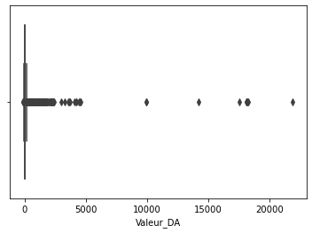

```python
sns.boxplot(x=df['Valeur_DA'])
```

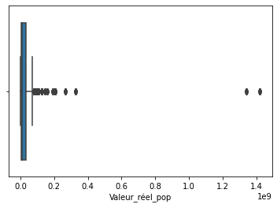

```python
sns.boxplot(x=df['Valeur_réel_pop'])
```

### Suppression du signe négatif devant les zéros.

```python
df['Valeur_DA'] = df['Valeur_DA'].mask(df['Valeur_DA'] == -0, 0)
```

```python
#Avant la ligne avec l'index 13 code zone 202 avait comme Valeur_DA -0 et maintenant les signes - sont retirés des 0.

df[df.Valeur_DA == -0]
```

|  | Code zone | Zone | Code Élément | Élément | Code Produit | Produit | Année | Valeur_DA | Valeur_réel_pop |
| --- | --- | --- | --- | --- | --- | --- | --- | --- | --- |
| 2 | 2 | Afghanistan | 5072 | Variation de stock | 2734 | Viande de Volailles | 2017 | 0.0 | 36296113.0 |
| 5 | 2 | Afghanistan | 5170 | Résidus | 2734 | Viande de Volailles | 2017 | 0.0 | 36296113.0 |
| 13 | 202 | Afrique du Sud | 5072 | Variation de stock | 2734 | Viande de Volailles | 2017 | 0.0 | 57009756.0 |
| 17 | 202 | Afrique du Sud | 5171 | Alimentation pour touristes | 2734 | Viande de Volailles | 2017 | 0.0 | 57009756.0 |
| 18 | 202 | Afrique du Sud | 5170 | Résidus | 2734 | Viande de Volailles | 2017 | 0.0 | 57009756.0 |
| ... | ... | ... | ... | ... | ... | ... | ... | ... | ... |
| 2041 | 251 | Zambie | 5171 | Alimentation pour touristes | 2734 | Viande de Volailles | 2017 | 0.0 | 16853599.0 |
| 2042 | 251 | Zambie | 5170 | Résidus | 2734 | Viande de Volailles | 2017 | 0.0 | 16853599.0 |
| 2050 | 181 | Zimbabwe | 5072 | Variation de stock | 2734 | Viande de Volailles | 2017 | 0.0 | 14236595.0 |
| 2054 | 181 | Zimbabwe | 5171 | Alimentation pour touristes | 2734 | Viande de Volailles | 2017 | 0.0 | 14236595.0 |
| 2055 | 181 | Zimbabwe | 5170 | Résidus | 2734 | Viande de Volailles | 2017 | 0.0 | 14236595.0 |

383 rows × 9 columns

### Suppression des valeurs négatives hors "Variation de stock".

Faire un nouveau dataset avec toutes les valeurs de variation de stock.

Ensuite supprimer dans l'ancien dataset toutes les valeurs négatives et les toutes les valeurs de variation de stock.

Enfin rajouter le nouveau à la suite de l'ancien pour faire un seul dataset (les concaténer).

Dans le tout nouveau dataset les seules valeurs négatives peuvent être pour variation de stock.

```python
dfcopy = df.copy()
```

```python
dfcopy1 = dfcopy[(dfcopy.Élément == "Variation de stock")]
```

```python
dfcopy1
```

|  | Code zone | Zone | Code Élément | Élément | Code Produit | Produit | Année | Valeur_DA | Valeur_réel_pop |
| --- | --- | --- | --- | --- | --- | --- | --- | --- | --- |
| 2 | 2 | Afghanistan | 5072 | Variation de stock | 2734 | Viande de Volailles | 2017 | 0.0 | 36296113.0 |
| 13 | 202 | Afrique du Sud | 5072 | Variation de stock | 2734 | Viande de Volailles | 2017 | 0.0 | 57009756.0 |
| 26 | 3 | Albanie | 5072 | Variation de stock | 2734 | Viande de Volailles | 2017 | 4.0 | 2884169.0 |
| 37 | 4 | Algérie | 5072 | Variation de stock | 2734 | Viande de Volailles | 2017 | 0.0 | 41389189.0 |
| 50 | 79 | Allemagne | 5072 | Variation de stock | 2734 | Viande de Volailles | 2017 | -29.0 | 82658409.0 |
| ... | ... | ... | ... | ... | ... | ... | ... | ... | ... |
| 2000 | 236 | Venezuela (République bolivarienne du) | 5072 | Variation de stock | 2734 | Viande de Volailles | 2017 | -1.0 | 29402484.0 |
| 2013 | 237 | Viet Nam | 5072 | Variation de stock | 2734 | Viande de Volailles | 2017 | 2.0 | 94600648.0 |
| 2026 | 249 | Yémen | 5072 | Variation de stock | 2734 | Viande de Volailles | 2017 | 0.0 | 27834819.0 |
| 2037 | 251 | Zambie | 5072 | Variation de stock | 2734 | Viande de Volailles | 2017 | 0.0 | 16853599.0 |
| 2050 | 181 | Zimbabwe | 5072 | Variation de stock | 2734 | Viande de Volailles | 2017 | 0.0 | 14236595.0 |

169 rows × 9 columns

```python
dfcopy = dfcopy[(dfcopy.Valeur_DA >= 0) & (dfcopy.Élément != "Variation de stock")]
```

```python
dfcopy[(dfcopy.Valeur_DA < 0)]
```

|  | Code zone | Zone | Code Élément | Élément | Code Produit | Produit | Année | Valeur_DA | Valeur_réel_pop |
| --- | --- | --- | --- | --- | --- | --- | --- | --- | --- |

```python
dfcopy[(dfcopy.Élément == "Variation de stock")]
```

|  | Code zone | Zone | Code Élément | Élément | Code Produit | Produit | Année | Valeur_DA | Valeur_réel_pop |
| --- | --- | --- | --- | --- | --- | --- | --- | --- | --- |

```python
dfcopy1
```

|  | Code zone | Zone | Code Élément | Élément | Code Produit | Produit | Année | Valeur_DA | Valeur_réel_pop |
| --- | --- | --- | --- | --- | --- | --- | --- | --- | --- |
| 2 | 2 | Afghanistan | 5072 | Variation de stock | 2734 | Viande de Volailles | 2017 | 0.0 | 36296113.0 |
| 13 | 202 | Afrique du Sud | 5072 | Variation de stock | 2734 | Viande de Volailles | 2017 | 0.0 | 57009756.0 |
| 26 | 3 | Albanie | 5072 | Variation de stock | 2734 | Viande de Volailles | 2017 | 4.0 | 2884169.0 |
| 37 | 4 | Algérie | 5072 | Variation de stock | 2734 | Viande de Volailles | 2017 | 0.0 | 41389189.0 |
| 50 | 79 | Allemagne | 5072 | Variation de stock | 2734 | Viande de Volailles | 2017 | -29.0 | 82658409.0 |
| ... | ... | ... | ... | ... | ... | ... | ... | ... | ... |
| 2000 | 236 | Venezuela (République bolivarienne du) | 5072 | Variation de stock | 2734 | Viande de Volailles | 2017 | -1.0 | 29402484.0 |
| 2013 | 237 | Viet Nam | 5072 | Variation de stock | 2734 | Viande de Volailles | 2017 | 2.0 | 94600648.0 |
| 2026 | 249 | Yémen | 5072 | Variation de stock | 2734 | Viande de Volailles | 2017 | 0.0 | 27834819.0 |
| 2037 | 251 | Zambie | 5072 | Variation de stock | 2734 | Viande de Volailles | 2017 | 0.0 | 16853599.0 |
| 2050 | 181 | Zimbabwe | 5072 | Variation de stock | 2734 | Viande de Volailles | 2017 | 0.0 | 14236595.0 |

169 rows × 9 columns

```python
frames = [dfcopy, dfcopy1]
df = pd.concat(frames)
```

```python
df
```

|  | Code zone | Zone | Code Élément | Élément | Code Produit | Produit | Année | Valeur_DA | Valeur_réel_pop |
| --- | --- | --- | --- | --- | --- | --- | --- | --- | --- |
| 0 | 2 | Afghanistan | 5511 | Production | 2734 | Viande de Volailles | 2017 | 28.0 | 36296113.0 |
| 1 | 2 | Afghanistan | 5611 | Importations - Quantité | 2734 | Viande de Volailles | 2017 | 29.0 | 36296113.0 |
| 3 | 2 | Afghanistan | 5301 | Disponibilité intérieure | 2734 | Viande de Volailles | 2017 | 57.0 | 36296113.0 |
| 4 | 2 | Afghanistan | 5123 | Pertes | 2734 | Viande de Volailles | 2017 | 2.0 | 36296113.0 |
| 5 | 2 | Afghanistan | 5170 | Résidus | 2734 | Viande de Volailles | 2017 | 0.0 | 36296113.0 |
| ... | ... | ... | ... | ... | ... | ... | ... | ... | ... |
| 2000 | 236 | Venezuela (République bolivarienne du) | 5072 | Variation de stock | 2734 | Viande de Volailles | 2017 | -1.0 | 29402484.0 |
| 2013 | 237 | Viet Nam | 5072 | Variation de stock | 2734 | Viande de Volailles | 2017 | 2.0 | 94600648.0 |
| 2026 | 249 | Yémen | 5072 | Variation de stock | 2734 | Viande de Volailles | 2017 | 0.0 | 27834819.0 |
| 2037 | 251 | Zambie | 5072 | Variation de stock | 2734 | Viande de Volailles | 2017 | 0.0 | 16853599.0 |
| 2050 | 181 | Zimbabwe | 5072 | Variation de stock | 2734 | Viande de Volailles | 2017 | 0.0 | 14236595.0 |

2040 rows × 9 columns